# Homework 1 Solutions

Cynthia Rush (cgr2130)

October 2, 2017

# Part 1

1. Since **properties** is a **.csv** file I use **read.csv()** to import the data into R.

```r
setwd("/Users/cynthiarush/Dropbox/Stats_Comp_2017/Homework/HW1")
housing <- read.csv("properties.csv", as.is = TRUE)
```

2. The function **dim()** provides the dimension of its input object.

```r
orig_dim <- dim(housing)
orig_dim
```

```
## [1] 16319    17
```

```r
apply(is.na(housing), 2, sum)
```

```
##       cartodb_id              bbl         tract_10         sba_name
##                0                0                0                0
##         ccd_name          cd_name        boro_name        city_name
##                0                0                0                0
##  tax_delinquency    ser_violation   assessed_value       owner_name
##                0                0                0                0
##        res_units       year_built        buildings standard_address
##              504              253              319                0
##  applied_filters
##                0
```

The command **is.na(housing)** creates a matrix of the same dimensions as **housing** with each element being TRUE or FALSE depending on whether or not the corresponding element in **housing** is an NA value. Then the full call **apply(is.na(housing), 2, sum)** counts the number of NA values each column of *housing*.

```r
housing <- housing[housing$assessed_value != 0, ]
```

The call **housing$assessed_value != 0** returns a logical vector with TRUE where **housing$assessed_value** doesn’t equal $0$, therefore I filter using **housing$assessed_value != 0** to get only the rows where **assessed_value** doesn’t equal $0$. I reassign my **housing** dataframe, to be the filtered dataframe.

```r
new_dim <- dim(housing)
orig_dim[1] - new_dim[1]
```

```
## [1] 66
```

I removed 66 rows of my dataframe.

```r
housing$logValue <- log(housing$assessed_value)
summary(housing$logValue)
```

```
##    Min. 1st Qu.  Median    Mean 3rd Qu.    Max.
##   5.878  12.480  13.250  13.480  14.350  20.030
```

```r
housing$logUnits <- log(housing$res_units)
```

```r
housing$after2000 <- housing$year_built >= 2000
```

# Part 2: EDA

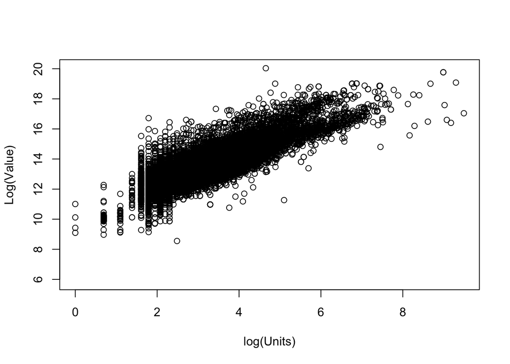

```r
plot(housing$logUnits, housing$logValue, xlab = "log(Units)", ylab = "Log(Value)")
```

I plot a scatterplot with the **plot()** command and add argument **xlab =** and **ylab =** for the labels.

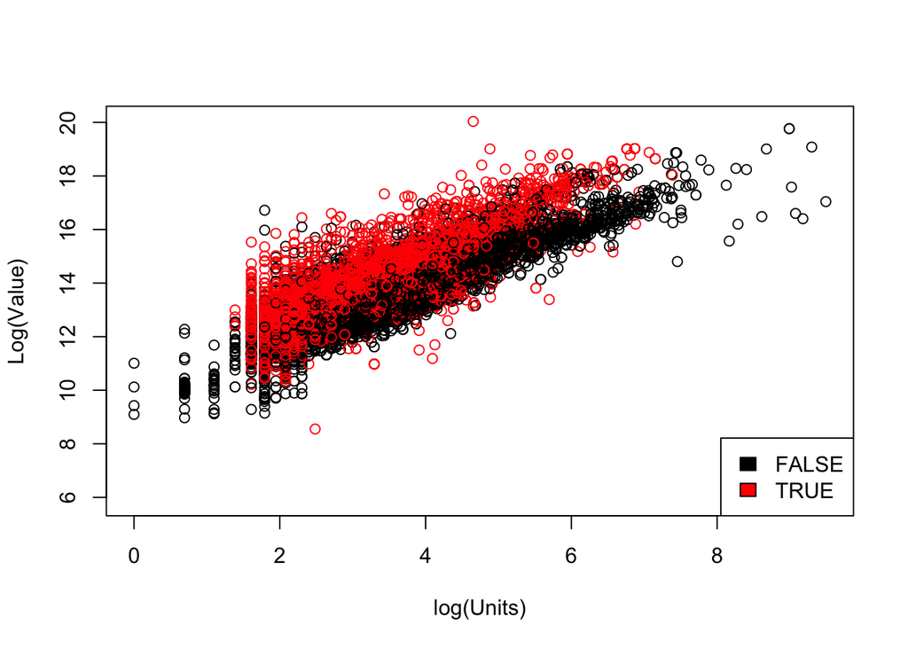

```r
plot(housing$logUnits, housing$logValue, col = factor(housing$after2000), xlab = "log(Units)", ylab = "Log(Value)")
legend("bottomright", legend = levels(factor(housing$after2000)), fill = unique(factor(housing$after2000)))
```

```r
cor(housing$logValue, housing$logUnits, use = "pairwise.complete.obs")
```

```
## [1] 0.8431877
```

```r
cor(housing$logValue[housing$boro_name == "Manhattan"], housing$logUnits[housing$boro_name == "Manhattan"], use = "pairwise.complete.obs")
```

```
## [1] 0.8592745
```

```r
cor(housing$logValue[housing$boro_name == "Brooklyn"], housing$logUnits[housing$boro_name == "Brooklyn"], use = "pairwise.complete.obs")
```

```
## [1] 0.8579328
```

```r
cor(housing$logValue[housing$after2000], housing$logUnits[housing$after2000], use = "pairwise.complete.obs")
```

```
## [1] 0.8337845
```

```r
cor(housing$logValue[!housing$after2000], housing$logUnits[!housing$after2000], use = "pairwise.complete.obs")
```

```
## [1] 0.8927153
```

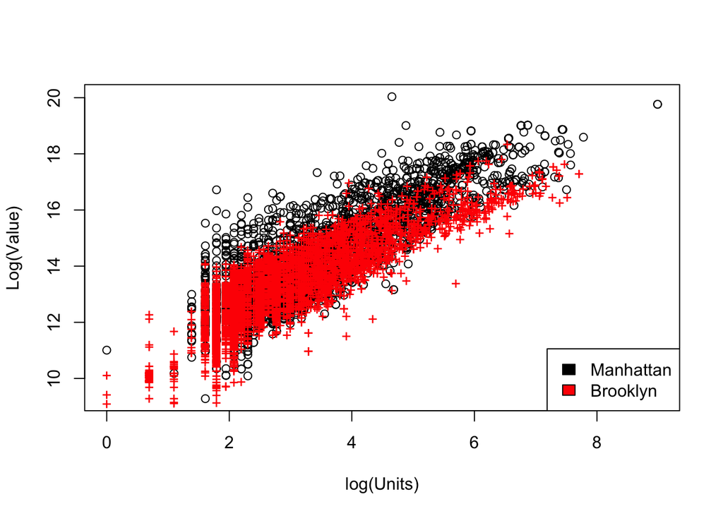

```r
plot(housing$logUnits[housing$boro_name == "Manhattan"], housing$logValue[housing$boro_name == "Manhattan"], xlab = "log(Units)", ylab = "Log(Value)")
points(housing$logUnits[housing$boro_name == "Brooklyn"], housing$logValue[housing$boro_name == "Brooklyn"], col = "red", pch = "+")
legend("bottomright", legend = c("Manhattan", "Brooklyn"), fill = c("black", "red"))
```

```r
median(housing$assessed_value[housing$boro_name == "Manhattan"])
```

```
## [1] 820350
```

The code calculates the median property value for all properties in Manhattan.

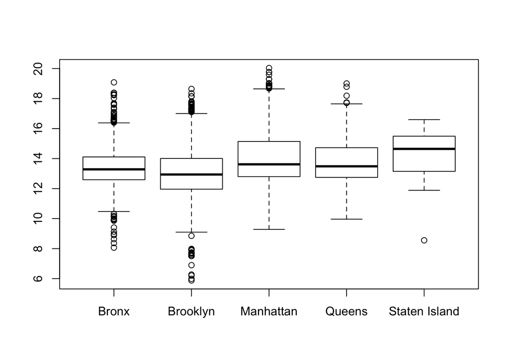

```r
boxplot(housing$logValue ~ housing$boro_name)
```

```r
tapply(housing$assessed_value, housing$boro_name, median)
```

```
##         Bronx      Brooklyn     Manhattan        Queens Staten Island
##        587250        416014        820350        719100       2296350
```

We use **tapply()** which splits the property value into groups based on **boro_name** and then calculated the median within each group.